# dataSetMushroom

```python
import pandas as pd
import numpy as np
import matplotlib.pyplot as plt
import seaborn as sns
import pandas.util.testing as tm

from collections import OrderedDict

from sklearn.linear_model import LogisticRegression
from sklearn.preprocessing import LabelEncoder
from sklearn.model_selection import train_test_split
from sklearn import metrics
from sklearn.metrics import roc_curve, roc_auc_score, make_scorer

from scipy import stats
```

```python
data = pd.read_csv("agaricus-lepiota.data")
data.head()
```

|  | p | x | s | n | t | p.1 | f | c | n.1 | k | ... | s.2 | w | w.1 | p.2 | w.2 | o | p.3 | k.1 | s.3 | u |
| --- | --- | --- | --- | --- | --- | --- | --- | --- | --- | --- | --- | --- | --- | --- | --- | --- | --- | --- | --- | --- | --- |
| 0 | e | x | s | y | t | a | f | c | b | k | ... | s | w | w | p | w | o | p | n | n | g |
| 1 | e | b | s | w | t | l | f | c | b | n | ... | s | w | w | p | w | o | p | n | n | m |
| 2 | p | x | y | w | t | p | f | c | n | n | ... | s | w | w | p | w | o | p | k | s | u |
| 3 | e | x | s | g | f | n | f | w | b | k | ... | s | w | w | p | w | o | e | n | a | g |
| 4 | e | x | y | y | t | a | f | c | b | n | ... | s | w | w | p | w | o | p | k | n | g |

5 rows × 23 columns

## Data quality analysis

#### Missing values

```python
data.isnull().sum().sum()
```

```
0
```

No missing values

```python
#Renaming columns for better understanding

column_name = {"p": "class", "x": "cap-shape", "s": "cap-surface", "n": "cap-color",
                "t": "bruises", "p.1": "odor", "f": "gill-attachment", "c": "gill-spacing",
                "n.1": "gill-size", "k": "gill-color", "e": "stalk-shape",
                "e.1": "stalk-root", "s.1": "stalk-surface-above-ring", "s.2": "stalk-surface-below-ring", "w": "stalk-color-above-ring",
                "w.1": "stalk-color-below-ring", "p.2": "veil-type", "w.2": "veil-color", "o": "ring-number",
                "p.3": "ring-type", "k.1": "spore-print-color", "s.3": "population", "u": "habitat"}
data = data.rename(index=str, columns=column_name)

data.head()
```

|  | class | cap-shape | cap-surface | cap-color | bruises | odor | gill-attachment | gill-spacing | gill-size | gill-color | ... | stalk-surface-below-ring | stalk-color-above-ring | stalk-color-below-ring | veil-type | veil-color | ring-number | ring-type | spore-print-color | population | habitat |
| --- | --- | --- | --- | --- | --- | --- | --- | --- | --- | --- | --- | --- | --- | --- | --- | --- | --- | --- | --- | --- | --- |
| 0 | e | x | s | y | t | a | f | c | b | k | ... | s | w | w | p | w | o | p | n | n | g |
| 1 | e | b | s | w | t | l | f | c | b | n | ... | s | w | w | p | w | o | p | n | n | m |
| 2 | p | x | y | w | t | p | f | c | n | n | ... | s | w | w | p | w | o | p | k | s | u |
| 3 | e | x | s | g | f | n | f | w | b | k | ... | s | w | w | p | w | o | e | n | a | g |
| 4 | e | x | y | y | t | a | f | c | b | n | ... | s | w | w | p | w | o | p | k | n | g |

5 rows × 23 columns

###### Using the LabelEncoder for changing the values p and e in the "class" column into 1 and 0, where 1 represents poisonous and 0 edible mushrooms. The reason why I have changed the values was for later classification, since we can't take a string as the value for prediction

```python
data["class"] = LabelEncoder().fit_transform(data["class"])
data
```

|  | class | cap-shape | cap-surface | cap-color | bruises | odor | gill-attachment | gill-spacing | gill-size | gill-color | ... | stalk-surface-below-ring | stalk-color-above-ring | stalk-color-below-ring | veil-type | veil-color | ring-number | ring-type | spore-print-color | population | habitat |
| --- | --- | --- | --- | --- | --- | --- | --- | --- | --- | --- | --- | --- | --- | --- | --- | --- | --- | --- | --- | --- | --- |
| 0 | 0 | x | s | y | t | a | f | c | b | k | ... | s | w | w | p | w | o | p | n | n | g |
| 1 | 0 | b | s | w | t | l | f | c | b | n | ... | s | w | w | p | w | o | p | n | n | m |
| 2 | 1 | x | y | w | t | p | f | c | n | n | ... | s | w | w | p | w | o | p | k | s | u |
| 3 | 0 | x | s | g | f | n | f | w | b | k | ... | s | w | w | p | w | o | e | n | a | g |
| 4 | 0 | x | y | y | t | a | f | c | b | n | ... | s | w | w | p | w | o | p | k | n | g |
| ... | ... | ... | ... | ... | ... | ... | ... | ... | ... | ... | ... | ... | ... | ... | ... | ... | ... | ... | ... | ... | ... |
| 8118 | 0 | k | s | n | f | n | a | c | b | y | ... | s | o | o | p | o | o | p | b | c | l |
| 8119 | 0 | x | s | n | f | n | a | c | b | y | ... | s | o | o | p | n | o | p | b | v | l |
| 8120 | 0 | f | s | n | f | n | a | c | b | n | ... | s | o | o | p | o | o | p | b | c | l |
| 8121 | 1 | k | y | n | f | y | f | c | n | b | ... | k | w | w | p | w | o | e | w | v | l |
| 8122 | 0 | x | s | n | f | n | a | c | b | y | ... | s | o | o | p | o | o | p | o | c | l |

8123 rows × 23 columns

###### Here I wanted to have an overview on how the mushrooms are divided, meaning that I have an almost evenly balanced dataset of poisonous and edible mushrooms

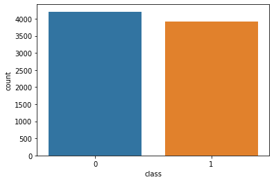

```python
x = data['class']
plt.figure(figsize=(6, 4))
ax = sns.countplot(x = x, data = data)
```

#### Disribution of each variable based on the mushroom being poisonous or edible

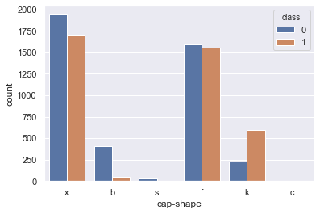

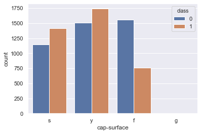

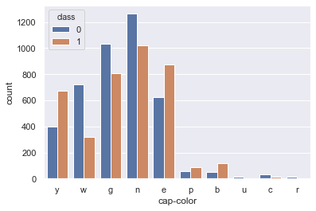

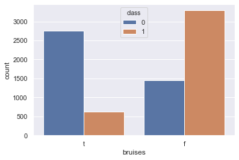

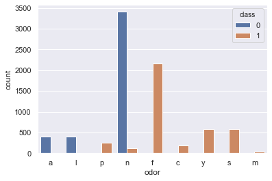

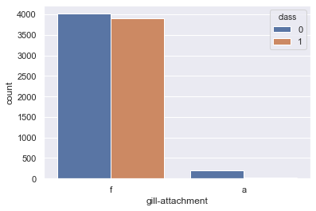

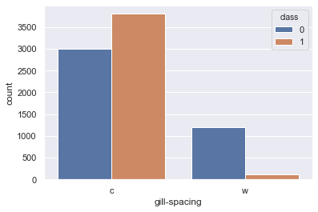

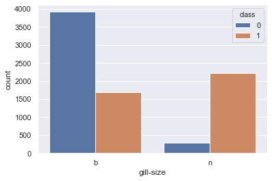

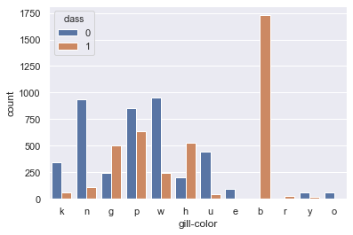

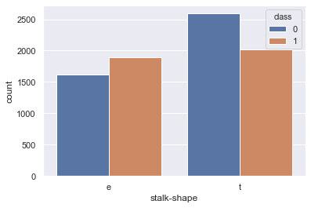

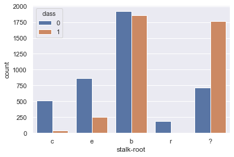

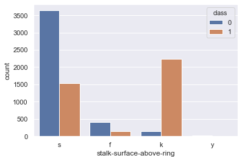

[10 more figures not shown]

```python
def mushroom_plot(hue, data):
    for i, col in enumerate(data.columns):
        plt.figure(i)
        sns.set(rc={'figure.figsize':(6, 4)})
        ax = sns.countplot(x = data[col], hue = hue, data = data)

hue = data['class']
data_for_plot = data.drop('class', 1)

mushroom_plot(hue, data_for_plot)
```

### Changing the rest of the characteristics with LabelEncoder

#### The reason I have used LabelEncoder is because if I have used One hot encoder it would change all of the values into numbers (1's or 0's) and in that case I needed to create dummy variables. I wanted to follow the steps of the project and create dummies after the univariant analysis. I am aware that if I have used the second approach, the outcome of the algorithm would be different, since the creation of dummies would increase the number of columns.

```python
for col in data.columns:
    data[col] = LabelEncoder().fit_transform(data[col])
data
```

|  | class | cap-shape | cap-surface | cap-color | bruises | odor | gill-attachment | gill-spacing | gill-size | gill-color | ... | stalk-surface-below-ring | stalk-color-above-ring | stalk-color-below-ring | veil-type | veil-color | ring-number | ring-type | spore-print-color | population | habitat |
| --- | --- | --- | --- | --- | --- | --- | --- | --- | --- | --- | --- | --- | --- | --- | --- | --- | --- | --- | --- | --- | --- |
| 0 | 0 | 5 | 2 | 9 | 1 | 0 | 1 | 0 | 0 | 4 | ... | 2 | 7 | 7 | 0 | 2 | 1 | 4 | 3 | 2 | 1 |
| 1 | 0 | 0 | 2 | 8 | 1 | 3 | 1 | 0 | 0 | 5 | ... | 2 | 7 | 7 | 0 | 2 | 1 | 4 | 3 | 2 | 3 |
| 2 | 1 | 5 | 3 | 8 | 1 | 6 | 1 | 0 | 1 | 5 | ... | 2 | 7 | 7 | 0 | 2 | 1 | 4 | 2 | 3 | 5 |
| 3 | 0 | 5 | 2 | 3 | 0 | 5 | 1 | 1 | 0 | 4 | ... | 2 | 7 | 7 | 0 | 2 | 1 | 0 | 3 | 0 | 1 |
| 4 | 0 | 5 | 3 | 9 | 1 | 0 | 1 | 0 | 0 | 5 | ... | 2 | 7 | 7 | 0 | 2 | 1 | 4 | 2 | 2 | 1 |
| ... | ... | ... | ... | ... | ... | ... | ... | ... | ... | ... | ... | ... | ... | ... | ... | ... | ... | ... | ... | ... | ... |
| 8118 | 0 | 3 | 2 | 4 | 0 | 5 | 0 | 0 | 0 | 11 | ... | 2 | 5 | 5 | 0 | 1 | 1 | 4 | 0 | 1 | 2 |
| 8119 | 0 | 5 | 2 | 4 | 0 | 5 | 0 | 0 | 0 | 11 | ... | 2 | 5 | 5 | 0 | 0 | 1 | 4 | 0 | 4 | 2 |
| 8120 | 0 | 2 | 2 | 4 | 0 | 5 | 0 | 0 | 0 | 5 | ... | 2 | 5 | 5 | 0 | 1 | 1 | 4 | 0 | 1 | 2 |
| 8121 | 1 | 3 | 3 | 4 | 0 | 8 | 1 | 0 | 1 | 0 | ... | 1 | 7 | 7 | 0 | 2 | 1 | 0 | 7 | 4 | 2 |
| 8122 | 0 | 5 | 2 | 4 | 0 | 5 | 0 | 0 | 0 | 11 | ... | 2 | 5 | 5 | 0 | 1 | 1 | 4 | 4 | 1 | 2 |

8123 rows × 23 columns

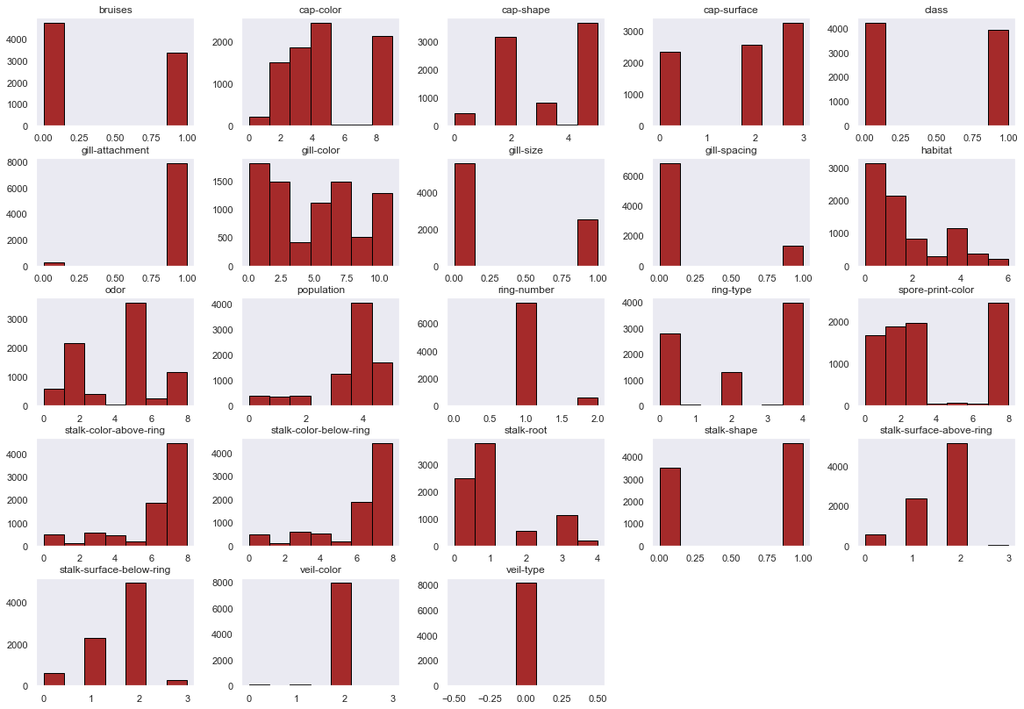

```python
data.hist(bins=7, color='brown', ec='black', figsize=(20, 14), grid=False);
```

#### Extremes

```python
data.describe()
```

|  | class | cap-shape | cap-surface | cap-color | bruises | odor | gill-attachment | gill-spacing | gill-size | gill-color | ... | stalk-surface-below-ring | stalk-color-above-ring | stalk-color-below-ring | veil-type | veil-color | ring-number | ring-type | spore-print-color | population | habitat |
| --- | --- | --- | --- | --- | --- | --- | --- | --- | --- | --- | --- | --- | --- | --- | --- | --- | --- | --- | --- | --- | --- |
| count | 8123.000000 | 8123.000000 | 8123.000000 | 8123.000000 | 8123.000000 | 8123.000000 | 8123.000000 | 8123.000000 | 8123.000000 | 8123.000000 | ... | 8123.000000 | 8123.000000 | 8123.000000 | 8123.0 | 8123.000000 | 8123.000000 | 8123.000000 | 8123.000000 | 8123.000000 | 8123.000000 |
| mean | 0.481965 | 3.347901 | 1.827650 | 4.504740 | 0.415487 | 4.144528 | 0.974147 | 0.161517 | 0.309122 | 4.810784 | ... | 1.603595 | 5.816201 | 5.794534 | 0.0 | 1.965530 | 1.069432 | 2.291764 | 3.596947 | 3.644097 | 1.508187 |
| std | 0.499705 | 1.604323 | 1.229947 | 2.545972 | 0.492836 | 2.103758 | 0.158705 | 0.368030 | 0.462160 | 3.540565 | ... | 0.676001 | 1.901819 | 1.907362 | 0.0 | 0.242684 | 0.271080 | 1.801683 | 2.382744 | 1.252139 | 1.719645 |
| min | 0.000000 | 0.000000 | 0.000000 | 0.000000 | 0.000000 | 0.000000 | 0.000000 | 0.000000 | 0.000000 | 0.000000 | ... | 0.000000 | 0.000000 | 0.000000 | 0.0 | 0.000000 | 0.000000 | 0.000000 | 0.000000 | 0.000000 | 0.000000 |
| 25% | 0.000000 | 2.000000 | 0.000000 | 3.000000 | 0.000000 | 2.000000 | 1.000000 | 0.000000 | 0.000000 | 2.000000 | ... | 1.000000 | 6.000000 | 6.000000 | 0.0 | 2.000000 | 1.000000 | 0.000000 | 2.000000 | 3.000000 | 0.000000 |
| 50% | 0.000000 | 3.000000 | 2.000000 | 4.000000 | 0.000000 | 5.000000 | 1.000000 | 0.000000 | 0.000000 | 5.000000 | ... | 2.000000 | 7.000000 | 7.000000 | 0.0 | 2.000000 | 1.000000 | 2.000000 | 3.000000 | 4.000000 | 1.000000 |
| 75% | 1.000000 | 5.000000 | 3.000000 | 8.000000 | 1.000000 | 5.000000 | 1.000000 | 0.000000 | 1.000000 | 7.000000 | ... | 2.000000 | 7.000000 | 7.000000 | 0.0 | 2.000000 | 1.000000 | 4.000000 | 7.000000 | 4.000000 | 2.000000 |
| max | 1.000000 | 5.000000 | 3.000000 | 9.000000 | 1.000000 | 8.000000 | 1.000000 | 1.000000 | 1.000000 | 11.000000 | ... | 3.000000 | 8.000000 | 8.000000 | 0.0 | 3.000000 | 2.000000 | 4.000000 | 8.000000 | 5.000000 | 6.000000 |

8 rows × 23 columns

I have noticed from the distribution of all values that the "veil-type" was 0, meaning there was no maximum value.

```python
maxValue = data['veil-type'].max()
print("Maximum value in column 'veil-type': " , maxValue)
```

```
Maximum value in column 'veil-type':  0
```

#### Value transformation

```python
data.drop("veil-type",axis=1,inplace=True)
```

## Univariant analysis

#### WoE, IV for each variable

###### WOE = In(% of non-events ➗ % of events)

###### IV = ∑ (% of non-events - % of events) * WOE

Information Value: Less than 0.02, 0.02 to 0.1, 0.1 to 0.3, 0.3 to 0.5, >0.5

Variable Predictiveness: Not useful for prediction, Weak predictive Power, Medium predictive Power, Strong predictive Power, Suspicious Predictive Power

```python
 def calc_iv(data, feature, target):
    lst = []
    for i in range(data[feature].nunique()):
        val = list(data[feature].unique())[i]

        lst.append({
            'Value': val,
            'All': data[data[feature] == val].count()[feature],
            'Good': data[(data[feature] == val) & (data[target] == 0)].count()[feature], #edible
            'Bad': data[(data[feature] == val) & (data[target] == 1)].count()[feature]   #poisonous
        })

    woe_data = pd.DataFrame(lst)

    woe_data['Distribution Good'] = woe_data['Good'] / woe_data['Good'].sum()
    woe_data['Distribution Bad'] = woe_data['Bad'] / woe_data['Bad'].sum()

    woe_data['WoE'] = np.log(woe_data['Distribution Good'] / woe_data['Distribution Bad'])
    woe_data = woe_data.replace({'WoE': {np.inf: 0, -np.inf: 0}})
    woe_data['IV'] = (woe_data['Distribution Good'] - woe_data['Distribution Bad']) * woe_data['WoE']

    iv = woe_data['IV'].sum()

    return woe_data, iv
```

```python
iv, woe_data = calc_iv(data, "cap-shape", "class")
iv, woe_data
```

```
(   Value   All  Good   Bad  Distribution Good  Distribution Bad       WoE  \
 0      5  3655  1948  1707           0.462928          0.436015  0.059894
 1      0   452   404    48           0.096008          0.012261  2.058042
 2      4    32    32     0           0.007605          0.000000  0.000000
 3      2  3152  1596  1556           0.379278          0.397446 -0.046790
 4      3   828   228   600           0.054183          0.153257 -1.039756
 5      1     4     0     4           0.000000          0.001022  0.000000

          IV
 0  0.001612
 1  0.172355
 2  0.000000
 3  0.000850
 4  0.103013
 5 -0.000000  , 0.2778299386419109)
```

###### IV = 0.27 - medium predictive power

```python
iv, woe_data = calc_iv(data, "cap-surface", "class")
iv, woe_data
```

```
(   Value   All  Good   Bad  Distribution Good  Distribution Bad       WoE  \
 0      2  2555  1144  1411           0.271863          0.360409 -0.281940
 1      3  3244  1504  1740           0.357414          0.444444 -0.217929
 2      0  2320  1560   760           0.370722          0.194125  0.646951
 3      1     4     0     4           0.000000          0.001022  0.000000

          IV
 0  0.024965
 1  0.018966
 2  0.114250
 3 -0.000000  , 0.1581805916876749)
```

###### IV = 0.16 - medium predictive power

```python
iv, woe_data = calc_iv(data, "cap-color", "class")
iv, woe_data
```

```
(   Value   All  Good   Bad  Distribution Good  Distribution Bad       WoE  \
 0      9  1072   400   672           0.095057          0.171648 -0.590966
 1      8  1040   720   320           0.171103          0.081737  0.738758
 2      3  1840  1032   808           0.245247          0.206386  0.172520
 3      4  2283  1264  1019           0.300380          0.260281  0.143287
 4      2  1500   624   876           0.148289          0.223755 -0.411388
 5      5   144    56    88           0.013308          0.022478 -0.524157
 6      0   168    48   120           0.011407          0.030651 -0.988463
 7      7    16    16     0           0.003802          0.000000  0.000000
 8      1    44    32    12           0.007605          0.003065  0.908657
 9      6    16    16     0           0.003802          0.000000  0.000000

          IV
 0  0.045262
 1  0.066020
 2  0.006704
 3  0.005746
 4  0.031046
 5  0.004806
 6  0.019022
 7  0.000000
 8  0.004125
 9  0.000000  , 0.18273144151428705)
```

###### IV = 0.18 - medium predictive power

```python
iv, woe_data = calc_iv(data, "bruises", "class")
iv, woe_data
```

```
(   Value   All  Good   Bad  Distribution Good  Distribution Bad       WoE  \
 0      1  3375  2752   623           0.653992          0.159132  1.413365
 1      0  4748  1456  3292           0.346008          0.840868 -0.887974

          IV
 0  0.699419
 1  0.439424  , 1.1388425804902425)
```

###### IV = 1.14 - suspicious predictive power

```python
iv, woe_data = calc_iv(data, "odor", "class")
iv, woe_data
```

```
(   Value   All  Good   Bad  Distribution Good  Distribution Bad       WoE  \
 0      0   400   400     0           0.095057          0.000000  0.000000
 1      3   400   400     0           0.095057          0.000000  0.000000
 2      6   255     0   255           0.000000          0.065134  0.000000
 3      5  3528  3408   120           0.809886          0.030651  3.274217
 4      2  2160     0  2160           0.000000          0.551724  0.000000
 5      1   192     0   192           0.000000          0.049042  0.000000
 6      8   576     0   576           0.000000          0.147126  0.000000
 7      7   576     0   576           0.000000          0.147126  0.000000
 8      4    36     0    36           0.000000          0.009195  0.000000

          IV
 0  0.000000
 1  0.000000
 2 -0.000000
 3  2.551383
 4 -0.000000
 5 -0.000000
 6 -0.000000
 7 -0.000000
 8 -0.000000  , 2.5513831427654066)
```

###### IV = 2.55 - suspicious predictive power

```python
iv, woe_data = calc_iv(data, "gill-attachment", "class")
iv, woe_data
```

```
(   Value   All  Good   Bad  Distribution Good  Distribution Bad       WoE  \
 0      1  7913  4016  3897           0.954373          0.995402 -0.042093
 1      0   210   192    18           0.045627          0.004598  2.294951

          IV
 0  0.001727
 1  0.094161  , 0.09588816701643794)
```

###### IV = 0.1 - medium predictive power

```python
iv, woe_data = calc_iv(data, "gill-spacing", "class")
iv, woe_data
```

```
(   Value   All  Good   Bad  Distribution Good  Distribution Bad       WoE  \
 0      0  6811  3008  3803           0.714829          0.971392 -0.306687
 1      1  1312  1200   112           0.285171          0.028608  2.299406

          IV
 0  0.078685
 1  0.589943  , 0.6686274643578081)
```

###### IV = 0.66 - suspicious predictive power

```python
iv, woe_data = calc_iv(data, "gill-size", "class")
iv, woe_data
```

```
(   Value   All  Good   Bad  Distribution Good  Distribution Bad       WoE  \
 0      0  5612  3920  1692           0.931559          0.432184  0.768008
 1      1  2511   288  2223           0.068441          0.567816 -2.115825

          IV
 0  0.383524
 1  1.056590  , 1.4401140964793508)
```

###### IV = 1.44 - suspicious predictive power

```python
iv, woe_data = calc_iv(data, "gill-color", "class")
iv, woe_data
```

```
(    Value   All  Good   Bad  Distribution Good  Distribution Bad       WoE  \
 0       4   407   344    63           0.081749          0.016092  1.625335
 1       5  1048   936   112           0.222433          0.028608  2.050944
 2       2   752   248   504           0.058935          0.128736 -0.781320
 3       7  1492   852   640           0.202471          0.163474  0.213946
 4      10  1202   956   246           0.227186          0.062835  1.285254
 5       3   732   204   528           0.048479          0.134866 -1.023148
 6       9   492   444    48           0.105513          0.012261  2.152451
 7       1    96    96     0           0.022814          0.000000  0.000000
 8       0  1728     0  1728           0.000000          0.441379  0.000000
 9       8    24     0    24           0.000000          0.006130  0.000000
 10     11    86    64    22           0.015209          0.005619  0.995668
 11      6    64    64     0           0.015209          0.000000  0.000000

           IV
 0   0.106715
 1   0.397525
 2   0.054536
 3   0.008343
 4   0.211233
 5   0.088387
 6   0.200722
 7   0.000000
 8  -0.000000
 9  -0.000000
 10  0.009548
 11  0.000000  , 1.0770095744030201)
```

###### IV = 1.1 - suspicious predictive power

```python
iv, woe_data = calc_iv(data, "stalk-shape", "class")
iv, woe_data
```

```
(   Value   All  Good   Bad  Distribution Good  Distribution Bad       WoE  \
 0      0  3515  1616  1899            0.38403          0.485057 -0.233546
 1      1  4608  2592  2016            0.61597          0.514943  0.179142

          IV
 0  0.023594
 1  0.018098  , 0.04169264235252346)
```

###### IV = 0.04 - weak predictive power

```python
iv, woe_data = calc_iv(data, "stalk-root", "class")
iv, woe_data
```

```
(   Value   All  Good   Bad  Distribution Good  Distribution Bad       WoE  \
 0      2   556   512    44           0.121673          0.011239  2.381963
 1      3  1119   864   255           0.205323          0.065134  1.148137
 2      1  3776  1920  1856           0.456274          0.474074 -0.038271
 3      4   192   192     0           0.045627          0.000000  0.000000
 4      0  2480   720  1760           0.171103          0.449553 -0.965990

          IV
 0  0.263050
 1  0.160956
 2  0.000681
 3  0.000000
 4  0.268980  , 0.6936678859044436)
```

###### IV = 0.7 - suspicious predictive power

```python
iv, woe_data = calc_iv(data, "stalk-surface-above-ring", "class")
iv, woe_data
```

```
(   Value   All  Good   Bad  Distribution Good  Distribution Bad       WoE  \
 0      2  5175  3640  1535           0.865019          0.392082  0.791281
 1      0   552   408   144           0.096958          0.036782  0.969282
 2      1  2372   144  2228           0.034221          0.569093 -2.811218
 3      3    24    16     8           0.003802          0.002043  0.620975

          IV
 0  0.374226
 1  0.058328
 2  1.503644
 3  0.001092  , 1.9372906036058524)
```

###### IV = 1.94 - suspicious predictive power

```python
iv, woe_data = calc_iv(data, "stalk-surface-below-ring", "class")
iv, woe_data
```

```
(   Value   All  Good   Bad  Distribution Good  Distribution Bad       WoE  \
 0      2  4935  3400  1535           0.807985          0.392082  0.723073
 1      0   600   456   144           0.108365          0.036782  1.080507
 2      3   284   208    76           0.049430          0.019413  0.934633
 3      1  2304   144  2160           0.034221          0.551724 -2.780222

          IV
 0  0.300728
 1  0.077346
 2  0.028055
 3  1.438775  , 1.8449047188408965)
```

###### IV = 1.84 - suspicious predictive power

```python
iv, woe_data = calc_iv(data, "stalk-color-above-ring", "class")
iv, woe_data
```

```
(   Value   All  Good   Bad  Distribution Good  Distribution Bad       WoE  \
 0      7  4463  2752  1711           0.653992          0.437037  0.403078
 1      3   576   576     0           0.136882          0.000000  0.000000
 2      6  1872   576  1296           0.136882          0.331034 -0.883102
 3      4   448    16   432           0.003802          0.110345 -3.368009
 4      0   432     0   432           0.000000          0.110345  0.000000
 5      2    96    96     0           0.022814          0.000000  0.000000
 6      5   192   192     0           0.045627          0.000000  0.000000
 7      1    36     0    36           0.000000          0.009195  0.000000
 8      8     8     0     8           0.000000          0.002043  0.000000

          IV
 0  0.087450
 1  0.000000
 2  0.171456
 3  0.358836
 4 -0.000000
 5  0.000000
 6  0.000000
 7 -0.000000
 8 -0.000000  , 0.6177425418514553)
```

###### IV = 0.61 - suspicious predictive power

```python
iv, woe_data = calc_iv(data, "stalk-color-below-ring", "class")
iv, woe_data
```

```
(   Value   All  Good   Bad  Distribution Good  Distribution Bad       WoE  \
 0      7  4383  2704  1679           0.642586          0.428863  0.404362
 1      6  1872   576  1296           0.136882          0.331034 -0.883102
 2      3   576   576     0           0.136882          0.000000  0.000000
 3      0   432     0   432           0.000000          0.110345  0.000000
 4      4   512    64   448           0.015209          0.114432 -2.018082
 5      2    96    96     0           0.022814          0.000000  0.000000
 6      8    24     0    24           0.000000          0.006130  0.000000
 7      5   192   192     0           0.045627          0.000000  0.000000
 8      1    36     0    36           0.000000          0.009195  0.000000

          IV
 0  0.086421
 1  0.171456
 2  0.000000
 3 -0.000000
 4  0.200239
 5  0.000000
 6 -0.000000
 7  0.000000
 8 -0.000000  , 0.45811672866950787)
```

###### IV = 0.46 - strong predictive power

```python
iv, woe_data = calc_iv(data, "veil-color", "class")
iv, woe_data
```

```
(   Value   All  Good   Bad  Distribution Good  Distribution Bad       WoE  \
 0      2  7923  4016  3907           0.954373          0.997957 -0.044656
 1      0    96    96     0           0.022814          0.000000  0.000000
 2      1    96    96     0           0.022814          0.000000  0.000000
 3      3     8     0     8           0.000000          0.002043  0.000000

          IV
 0  0.001946
 1  0.000000
 2  0.000000
 3 -0.000000  , 0.0019462667167293628)
```

###### IV = 0.00 - not useful for prediction

```python
iv, woe_data = calc_iv(data, "ring-number", "class")
iv, woe_data
```

```
(   Value   All  Good   Bad  Distribution Good  Distribution Bad       WoE  \
 0      1  7487  3680  3807           0.874525          0.972414 -0.106101
 1      2   600   528    72           0.125475          0.018391  1.920258
 2      0    36     0    36           0.000000          0.009195  0.000000

          IV
 0  0.010386
 1  0.205630
 2 -0.000000  , 0.21601594898622317)
```

###### IV = 0.2 - medium predictive power

```python
iv, woe_data = calc_iv(data, "ring-type", "class")
iv, woe_data
```

```
(   Value   All  Good   Bad  Distribution Good  Distribution Bad       WoE  \
 0      4  3967  3152   815           0.749049          0.208174  1.280432
 1      0  2776  1008  1768           0.239544          0.451596 -0.634053
 2      2  1296     0  1296           0.000000          0.331034  0.000000
 3      1    48    48     0           0.011407          0.000000  0.000000
 4      3    36     0    36           0.000000          0.009195  0.000000

          IV
 0  0.692555
 1  0.134453
 2 -0.000000
 3  0.000000
 4 -0.000000  , 0.827007344174926)
```

###### IV = 0.83 - suspicious predictive power

```python
iv, woe_data = calc_iv(data, "spore-print-color", "class")
iv, woe_data
```

```
(   Value   All  Good   Bad  Distribution Good  Distribution Bad       WoE  \
 0      3  1968  1744   224           0.414449          0.057216  1.980118
 1      2  1871  1648   223           0.391635          0.056960  1.927974
 2      6    48    48     0           0.011407          0.000000  0.000000
 3      1  1632    48  1584           0.011407          0.404598 -3.568680
 4      7  2388   576  1812           0.136882          0.462835 -1.218251
 5      5    72     0    72           0.000000          0.018391  0.000000
 6      4    48    48     0           0.011407          0.000000  0.000000
 7      8    48    48     0           0.011407          0.000000  0.000000
 8      0    48    48     0           0.011407          0.000000  0.000000

          IV
 0  0.707363
 1  0.645244
 2  0.000000
 3  1.403172
 4  0.397093
 5 -0.000000
 6  0.000000
 7  0.000000
 8  0.000000  , 3.152872049655753)
```

###### IV = 3.15 - suspicious predictive power

```python
iv, woe_data = calc_iv(data, "population", "class")
iv, woe_data
```

```
(   Value   All  Good   Bad  Distribution Good  Distribution Bad       WoE  \
 0      2   400   400     0           0.095057          0.000000  0.000000
 1      3  1247   880   367           0.209125          0.093742  0.802388
 2      0   384   384     0           0.091255          0.000000  0.000000
 3      4  4040  1192  2848           0.283270          0.727458 -0.943157
 4      5  1712  1064   648           0.252852          0.165517  0.423728
 5      1   340   288    52           0.068441          0.013282  1.639545

          IV
 0  0.000000
 1  0.092582
 2  0.000000
 3  0.418939
 4  0.037006
 5  0.090435  , 0.6389630096611244)
```

###### IV = 0.64 - suspicious predictive power

```python
iv, woe_data = calc_iv(data, "habitat", "class")
iv, woe_data
```

```
(   Value   All  Good   Bad  Distribution Good  Distribution Bad       WoE  \
 0      1  2148  1408   740           0.334601          0.189017  0.571103
 1      3   292   256    36           0.060837          0.009195  1.889486
 2      5   367    96   271           0.022814          0.069221 -1.109943
 3      0  3148  1880  1268           0.446768          0.323883  0.321659
 4      4  1144   136  1008           0.032319          0.257471 -2.075241
 5      6   192   192     0           0.045627          0.000000  0.000000
 6      2   832   240   592           0.057034          0.151213 -0.975040

          IV
 0  0.083144
 1  0.097575
 2  0.051509
 3  0.039527
 4  0.467244
 5  0.000000
 6  0.091828  , 0.8308280205769273)
```

###### IV = 0.83 - suspicious predictive power

#### Selection of most predictvie values

The results that I have got are mixed, which is something that I have expected, since there are 21 different characteristics of mushrooms. Most of the predictive values are either medium or suspicious, where only one has strong predictive power.

#### Coarse classing - grouping by WoE

Since I have decided what values to use, the rest of the values(most of them are suspicious or too good to be true for prediction) will be dropped. I will also store the values that have suspicious predictive powers for later testing if needed.

```python
data2 = ['odor', 'bruises', 'gill-attachment', 'gill-spacing', 'gill-size', 'gill-color', 'stalk-root', 'stalk-surface-above-ring', 'stalk-surface-below-ring', 'stalk-color-above-ring', 'spore-print-color', 'ring-type', 'population', 'habitat']
x2 = data[data2]
x2
```

|  | odor | bruises | gill-attachment | gill-spacing | gill-size | gill-color | stalk-root | stalk-surface-above-ring | stalk-surface-below-ring | stalk-color-above-ring | spore-print-color | ring-type | population | habitat |
| --- | --- | --- | --- | --- | --- | --- | --- | --- | --- | --- | --- | --- | --- | --- |
| 0 | 0 | 1 | 1 | 0 | 0 | 4 | 2 | 2 | 2 | 7 | 3 | 4 | 2 | 1 |
| 1 | 3 | 1 | 1 | 0 | 0 | 5 | 2 | 2 | 2 | 7 | 3 | 4 | 2 | 3 |
| 2 | 6 | 1 | 1 | 0 | 1 | 5 | 3 | 2 | 2 | 7 | 2 | 4 | 3 | 5 |
| 3 | 5 | 0 | 1 | 1 | 0 | 4 | 3 | 2 | 2 | 7 | 3 | 0 | 0 | 1 |
| 4 | 0 | 1 | 1 | 0 | 0 | 5 | 2 | 2 | 2 | 7 | 2 | 4 | 2 | 1 |
| ... | ... | ... | ... | ... | ... | ... | ... | ... | ... | ... | ... | ... | ... | ... |
| 8118 | 5 | 0 | 0 | 0 | 0 | 11 | 0 | 2 | 2 | 5 | 0 | 4 | 1 | 2 |
| 8119 | 5 | 0 | 0 | 0 | 0 | 11 | 0 | 2 | 2 | 5 | 0 | 4 | 4 | 2 |
| 8120 | 5 | 0 | 0 | 0 | 0 | 5 | 0 | 2 | 2 | 5 | 0 | 4 | 1 | 2 |
| 8121 | 8 | 0 | 1 | 0 | 1 | 0 | 0 | 2 | 1 | 7 | 7 | 0 | 4 | 2 |
| 8122 | 5 | 0 | 0 | 0 | 0 | 11 | 0 | 2 | 2 | 5 | 4 | 4 | 1 | 2 |

8123 rows × 14 columns

```python
data = data.drop(['odor', 'bruises', 'gill-attachment', 'gill-spacing', 'gill-size', 'gill-color','stalk-shape', 'stalk-root', 'stalk-surface-above-ring', 'stalk-surface-below-ring', 'stalk-color-above-ring','veil-color', 'spore-print-color', 'ring-type', 'population', 'habitat'], axis = 1)
data.head()
```

|  | class | cap-shape | cap-surface | cap-color | stalk-color-below-ring | ring-number |
| --- | --- | --- | --- | --- | --- | --- |
| 0 | 0 | 5 | 2 | 9 | 7 | 1 |
| 1 | 0 | 0 | 2 | 8 | 7 | 1 |
| 2 | 1 | 5 | 3 | 8 | 7 | 1 |
| 3 | 0 | 5 | 2 | 3 | 7 | 1 |
| 4 | 0 | 5 | 3 | 9 | 7 | 1 |

```python
class_poison_edible, class_iv = calc_iv(data, 'cap-shape', 'class')
class_poison_edible
```

|  | Value | All | Good | Bad | Distribution Good | Distribution Bad | WoE | IV |
| --- | --- | --- | --- | --- | --- | --- | --- | --- |
| 0 | 5 | 3655 | 1948 | 1707 | 0.462928 | 0.436015 | 0.059894 | 0.001612 |
| 1 | 0 | 452 | 404 | 48 | 0.096008 | 0.012261 | 2.058042 | 0.172355 |
| 2 | 4 | 32 | 32 | 0 | 0.007605 | 0.000000 | 0.000000 | 0.000000 |
| 3 | 2 | 3152 | 1596 | 1556 | 0.379278 | 0.397446 | -0.046790 | 0.000850 |
| 4 | 3 | 828 | 228 | 600 | 0.054183 | 0.153257 | -1.039756 | 0.103013 |
| 5 | 1 | 4 | 0 | 4 | 0.000000 | 0.001022 | 0.000000 | -0.000000 |

```python
test = data.iloc[[0, 2, 5]]
calc_iv(test, 'cap-shape', 'class')
```

```
(   Value  All  Good  Bad  Distribution Good  Distribution Bad       WoE  \
 0      5    2     1    1                0.5               1.0 -0.693147
 1      0    1     1    0                0.5               0.0  0.000000

          IV
 0  0.346574
 1  0.000000  , 0.34657359027997264)
```

```python
class_poison_edible, class_iv = calc_iv(data, 'cap-surface', 'class')
class_poison_edible
```

|  | Value | All | Good | Bad | Distribution Good | Distribution Bad | WoE | IV |
| --- | --- | --- | --- | --- | --- | --- | --- | --- |
| 0 | 2 | 2555 | 1144 | 1411 | 0.271863 | 0.360409 | -0.281940 | 0.024965 |
| 1 | 3 | 3244 | 1504 | 1740 | 0.357414 | 0.444444 | -0.217929 | 0.018966 |
| 2 | 0 | 2320 | 1560 | 760 | 0.370722 | 0.194125 | 0.646951 | 0.114250 |
| 3 | 1 | 4 | 0 | 4 | 0.000000 | 0.001022 | 0.000000 | -0.000000 |

```python
test2 = data.iloc[[1, 2]]
calc_iv(test2, 'cap-surface', 'class')
```

```
(   Value  All  Good  Bad  Distribution Good  Distribution Bad  WoE   IV
 0      2    1     1    0                1.0               0.0  0.0  0.0
 1      3    1     0    1                0.0               1.0  0.0 -0.0, 0.0)
```

```python
class_poison_edible, class_iv = calc_iv(data, 'stalk-color-below-ring', 'class')
class_poison_edible
```

|  | Value | All | Good | Bad | Distribution Good | Distribution Bad | WoE | IV |
| --- | --- | --- | --- | --- | --- | --- | --- | --- |
| 0 | 7 | 4383 | 2704 | 1679 | 0.642586 | 0.428863 | 0.404362 | 0.086421 |
| 1 | 6 | 1872 | 576 | 1296 | 0.136882 | 0.331034 | -0.883102 | 0.171456 |
| 2 | 3 | 576 | 576 | 0 | 0.136882 | 0.000000 | 0.000000 | 0.000000 |
| 3 | 0 | 432 | 0 | 432 | 0.000000 | 0.110345 | 0.000000 | -0.000000 |
| 4 | 4 | 512 | 64 | 448 | 0.015209 | 0.114432 | -2.018082 | 0.200239 |
| 5 | 2 | 96 | 96 | 0 | 0.022814 | 0.000000 | 0.000000 | 0.000000 |
| 6 | 8 | 24 | 0 | 24 | 0.000000 | 0.006130 | 0.000000 | -0.000000 |
| 7 | 5 | 192 | 192 | 0 | 0.045627 | 0.000000 | 0.000000 | 0.000000 |
| 8 | 1 | 36 | 0 | 36 | 0.000000 | 0.009195 | 0.000000 | -0.000000 |

```python
test3 = data.iloc[[2, 3, 5, 6, 7, 8]]
calc_iv(test3, 'stalk-color-below-ring', 'class')
```

```
(   Value  All  Good  Bad  Distribution Good  Distribution Bad  WoE   IV
 0      7    6     4    2                1.0               1.0  0.0  0.0, 0.0)
```

```python
class_poison_edible, class_iv = calc_iv(data, 'ring-number', 'class')
class_poison_edible
```

|  | Value | All | Good | Bad | Distribution Good | Distribution Bad | WoE | IV |
| --- | --- | --- | --- | --- | --- | --- | --- | --- |
| 0 | 1 | 7487 | 3680 | 3807 | 0.874525 | 0.972414 | -0.106101 | 0.010386 |
| 1 | 2 | 600 | 528 | 72 | 0.125475 | 0.018391 | 1.920258 | 0.205630 |
| 2 | 0 | 36 | 0 | 36 | 0.000000 | 0.009195 | 0.000000 | -0.000000 |

### Story telling - problem description

Now that I have calculated Woe and IV and decided what variables to use for modeling, I can proceed with preparing the predictive model. My target variable is "class" which will be used to help me indentify whether a mushroom is poisonous or edible. Because there are many characteristics of the mushroom, I am hoping that I will get aa good distribution of the variables (classification).

## Preparation for predictive model

### Correlation calculation

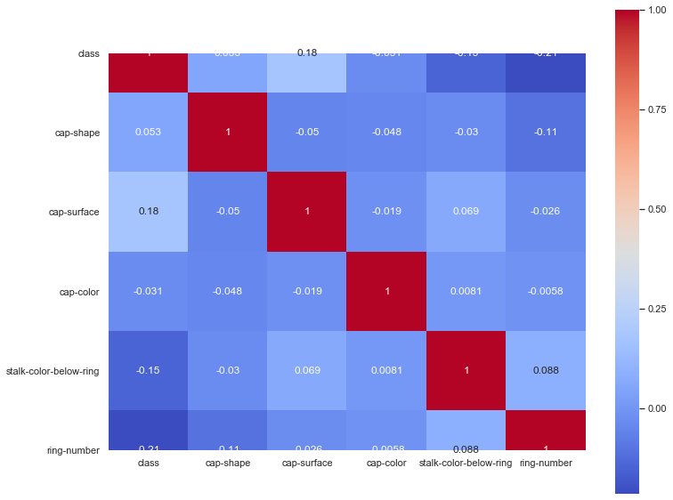

```python
plt.figure(figsize=(12, 10))
sns.heatmap(data.corr(method = 'pearson'), annot=True, square = True, cmap = 'coolwarm');
```

Based on this heatmap, we can see that there are no positive strong correlations. On the other hand there are negative correlations between ring-number and class and stalk-color-below-ring and class variables. For now, I don't think I will drop any variables and just proceed with creating dummy variables.

### Dummy Creation

```python
dummy_data = pd.get_dummies(data)

dummy_data.head()
```

|  | class | cap-shape | cap-surface | cap-color | stalk-color-below-ring | ring-number |
| --- | --- | --- | --- | --- | --- | --- |
| 0 | 0 | 5 | 2 | 9 | 7 | 1 |
| 1 | 0 | 0 | 2 | 8 | 7 | 1 |
| 2 | 1 | 5 | 3 | 8 | 7 | 1 |
| 3 | 0 | 5 | 2 | 3 | 7 | 1 |
| 4 | 0 | 5 | 3 | 9 | 7 | 1 |

Now, I wanna se the correlation between the dummy variables and see whether I will have to reduce variables if the correlations is high.

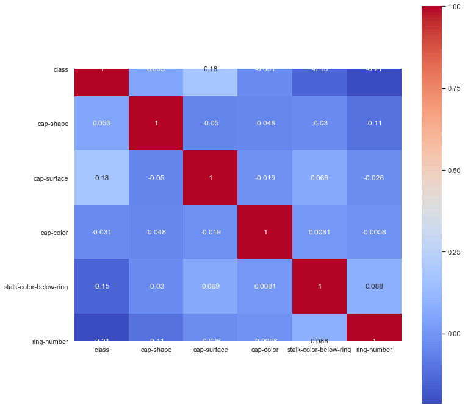

```python
plt.figure(figsize=(12, 12))
sns.heatmap(dummy_data.corr(method = 'pearson'), annot=True, square = True, cmap = 'coolwarm');
```

Based on what I see, the correlation is the same with dummy variables. I really want to focus on the ring number variable because of its negative correlation and see what results I will get.

## Model development

### Logistic regression

##### Splitting sample on 80:20 development testing

Before I start with prediction, I will split the data into a training set and test set, where we will train the algoithm on the training set and make predictions on the testing set

```python
y = data["class"].values
x = data.drop(["class"], axis=1).values

 # Split the data for training and testing.
x_train, x_test, y_train, y_test = train_test_split(x,y,random_state=5,test_size=0.2)
```

```python
lr = LogisticRegression(solver="lbfgs")
lr.fit(x_train, y_train)
```

```
LogisticRegression(C=1.0, class_weight=None, dual=False, fit_intercept=True,
                   intercept_scaling=1, l1_ratio=None, max_iter=100,
                   multi_class='warn', n_jobs=None, penalty='l2',
                   random_state=None, solver='lbfgs', tol=0.0001, verbose=0,
                   warm_start=False)
```

###### Logistic Regression

```python
lr = LogisticRegression(solver="lbfgs")
lr.fit(x_train,y_train)
print("Accuracy of Logistic Regression is: {}%".format(round(lr.score(x_test,y_test)*100,2)))
```

```
Accuracy of Logistic Regression is: 62.58%
```

##### Probability calculation based on logistic regression

I am putting 0.5 as the treshold of predicting whther a mushroom is poisonous or edible

```python
y_prob = lr.predict_proba(x_test)[:,1]
y_pred = np.where(y_prob > 0.5, 1, 0)
```

Confusion matrix

```python
confusion_matrix = metrics.confusion_matrix(y_test, y_pred)

print(confusion_matrix)
```

```
[[518 315]
 [293 499]]
```

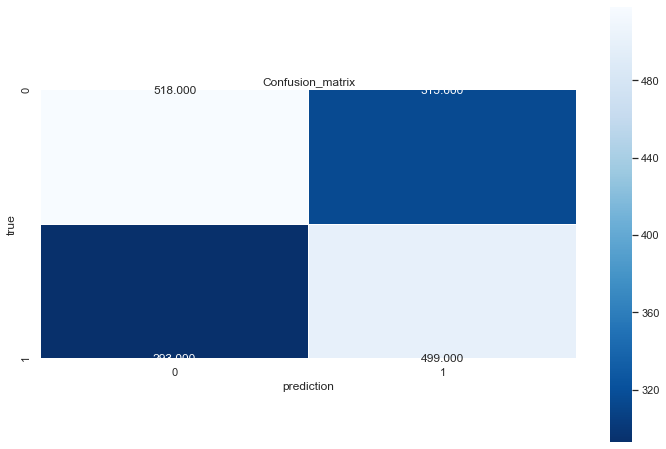

```python
plt.figure(figsize=(12,8))
sns.heatmap(confusion_matrix, annot=True, fmt=".3f", linewidths=.5, square = True, cmap = 'Blues_r');
plt.ylabel("true")
plt.xlabel("prediction")
plt.title("Confusion_matrix");
```

This confusion matrix shows us that we have 518+499 correct predictions/classifications and 315+293 incorrect predictions/classifications

```python
from sklearn.metrics import classification_report
print(classification_report(y_test, y_pred))
```

```
              precision    recall  f1-score   support

           0       0.64      0.62      0.63       833
           1       0.61      0.63      0.62       792

    accuracy                           0.63      1625
   macro avg       0.63      0.63      0.63      1625
weighted avg       0.63      0.63      0.63      1625
```

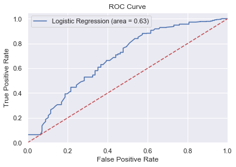

```python
logit_roc_auc = roc_auc_score(y_test, lr.predict(x_test))
fpr, tpr, thresholds = roc_curve(y_test, lr.predict_proba(x_test)[:,1])
plt.figure()
plt.plot(fpr, tpr, label='Logistic Regression (area = %0.2f)' % logit_roc_auc)
plt.plot([0, 1], [0, 1],'r--')
plt.xlim([0.0, 1.0])
plt.ylim([0.0, 1.05])
plt.xlabel('False Positive Rate')
plt.ylabel('True Positive Rate')
plt.title('ROC Curve')
plt.legend(loc="upper left")
plt.savefig('Log_ROC')
plt.show()
```

### Testing model with suspicious predictive power

```python
y2 = data["class"].values
x2.values
x_2_train, x_2_test, y_2_train, y_2_test = train_test_split(x2, y2, random_state=5,test_size=0.2)
```

```python
lr = LogisticRegression(solver="lbfgs")
lr.fit(x_2_train,y_2_train)
print("Accuracy of Logistic Regression is: {}%".format(round(lr.score(x_2_test,y_2_test)*100,2)))
```

```
Accuracy of Logistic Regression is: 93.66%
```

As we can see here, the accuracy of the algorythm is high. I wanted to test this as well, since there were a lot of variables that had a suspicious predictive power.

```
[[788  45]
 [ 58 734]]
```

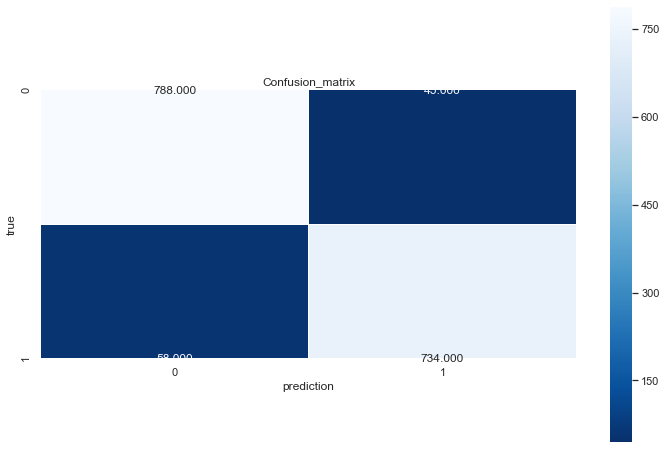

```python
y_prob2 = lr.predict_proba(x_2_test)[:,1]
y_pred2 = np.where(y_prob2 > 0.5, 1, 0)

confusion_matrix = metrics.confusion_matrix(y_2_test, y_pred2)
print(confusion_matrix)

plt.figure(figsize=(12,8))
sns.heatmap(confusion_matrix, annot=True, fmt=".3f", linewidths=.5, square = True, cmap = 'Blues_r');
plt.ylabel("true")
plt.xlabel("prediction")
plt.title("Confusion_matrix");
```

As expected as seen in the confusion matrix, 788+734 correct predictions/classifications and 45+58 incorrect predictions/classifications which is great. This means that only 45+58 mushrooms were incorrectly classified. But since I am testing variables that are to good to be true, I knew that the outcome of the matrix and logistics regression accuracy would be great.

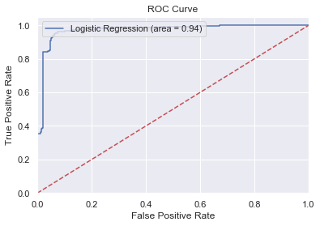

```python
logit_roc_auc = roc_auc_score(y_2_test, lr.predict(x_2_test))
fpr, tpr, thresholds = roc_curve(y_2_test, lr.predict_proba(x_2_test)[:,1])
plt.figure()
plt.plot(fpr, tpr, label='Logistic Regression (area = %0.2f)' % logit_roc_auc)
plt.plot([0, 1], [0, 1],'r--')
plt.xlim([0.0, 1.0])
plt.ylim([0.0, 1.05])
plt.xlabel('False Positive Rate')
plt.ylabel('True Positive Rate')
plt.title('ROC Curve')
plt.legend(loc="upper left")
plt.savefig('Log_ROC')
plt.show()
```

Based on the logistic regression and roc curve, I can conclude that this model performs better thahn the previous, but as said it is because these variables were of very strong predictive power.

## Project conclusion

It was interesting to see how WoE and IV work and I enjoyed doing some research about what variable to use and how it would influence the prediction.

It would be differernt if I didn't have to encode the dataset and use LabelEncoder in the very beginning. The next time I would definitely use One hot encoder, because I want to see if the predictive model would be more representative.